# Effect of Workplace Smoking Bans on Smoking Behaviour: A Logistic Regression Analysis

Joseph Jeremiah | josephjkunle@gmail.com | Data Scientist

April 10, 2026

# 1 Introduction

Tobacco smoking remains one of the leading causes of preventable disease and death globally, including in sub-Saharan Africa. Policy interventions such as workplace smoking bans have been adopted in many countries to reduce smoking rates among working-age populations. This analysis investigates whether workplace smoking bans are significantly associated with a reduction in the probability of an individual being a smoker, while controlling for key demographic factors.

The dataset used is the **SmokeBan** dataset, containing 10,000 individual observations collected from a survey of working-age adults. The outcome of interest — whether an individual is a smoker — is a binary variable, making **Binary Logistic Regression** the most appropriate statistical method. A preliminary **Chi-square test** is also conducted to assess the basic association between smoking bans and smoking status before fitting the full model.

**Research Question:** Does the presence of a workplace smoking ban significantly reduce the probability that an individual is a smoker, after controlling for age, education, ethnicity, and gender?

# 2 Dataset Description

## 2.1 Loading Required Libraries

```r
# install.packages(c("tidyverse", "ggplot2", "car", "ResourceSelection",
#                    "DescTools", "broom", "knitr", "kableExtra"))

library(tidyverse)       # Data manipulation and ggplot2
library(ggplot2)         # Data visualisation
library(car)             # VIF test for multicollinearity
library(ResourceSelection) # Hosmer-Lemeshow goodness-of-fit test
library(DescTools)       # Nagelkerke Pseudo R-squared
library(broom)           # Tidy model output
library(knitr)           # Table formatting
library(kableExtra)      # Enhanced tables
```

## 2.2 Loading and Preparing the Data

```r
# Load the dataset
data <- read.csv("SmokeBan.csv")

# Remove the row ID column — it carries no analytical information
data <- data %>% select(-rownames)

# Convert all categorical variables to factors with appropriate levels
data$smoker <- factor(data$smoker,
                      levels = c("no", "yes"))

data$ban <- factor(data$ban,
                   levels = c("no", "yes"))

data$afam <- factor(data$afam,
                    levels = c("no", "yes"))

data$hispanic <- factor(data$hispanic,
                        levels = c("no", "yes"))

data$gender <- factor(data$gender,
                      levels = c("male", "female"))

# Education is ordinal: order from lowest to highest
data$education <- factor(data$education,
                         levels = c("hs drop out", "hs", "some college",
                                    "college", "master"),
                         ordered = TRUE)

# Preview the cleaned dataset
glimpse(data)
```

```
## Rows: 10,000
## Columns: 7
## $ smoker    <fct> yes, yes, no, yes, no, no, yes, yes, no, no, no, no, no, no,…
## $ ban       <fct> yes, yes, no, no, yes, no, yes, no, yes, no, no, no, yes, ye…
## $ age       <int> 41, 44, 19, 29, 28, 40, 47, 36, 49, 44, 33, 49, 28, 32, 29, …
## $ education <ord> hs, some college, some college, hs, some college, some colle…
## $ afam      <fct> no, no, no, no, no, no, no, no, no, no, no, no, no, no, no, …
## $ hispanic  <fct> no, no, no, no, no, no, no, no, no, no, no, no, no, no, no, …
## $ gender    <fct> female, female, female, female, female, male, female, male, …
```

## 2.3 Variable Descriptions

The table below describes each variable in the dataset.

Table 1: Variable Descriptions — SmokeBan Dataset

| Variable | Type | Levels | Description |
| --- | --- | --- | --- |
| smoker | Binary (Outcome) | yes / no | Whether the individual is a current smoker |
| ban | Binary (Key Predictor) | yes / no | Whether the individual works under a workplace smoking ban |
| age | Continuous | 18 – 88 (years) | Age of the individual in years |
| education | Ordinal Categorical | hs drop out / hs / some college / college / master | Highest educational qualification attained |
| afam | Binary | yes / no | Whether the individual identifies as African-American |
| hispanic | Binary | yes / no | Whether the individual identifies as Hispanic |
| gender | Binary | male / female | Gender of the individual |

# 3 Descriptive Statistics

## 3.1 Overall Summary

```r
# Numeric summary
summary(data)
```

```
##  smoker      ban            age               education     afam
##  no :7577   no :3902   Min.   :18.00   hs drop out : 912   no :9231
##  yes:2423   yes:6098   1st Qu.:29.00   hs          :3266   yes: 769
##                        Median :37.00   some college:2802
##                        Mean   :38.69   college     :1972
##                        3rd Qu.:47.00   master      :1048
##                        Max.   :88.00
##  hispanic      gender
##  no :8866   male  :4363
##  yes:1134   female:5637
##
##
##
##
```

## 3.2 Frequency Tables for Categorical Variables

```r
# Smoking status distribution
smoker_freq <- data %>%
  count(smoker) %>%
  mutate(Percentage = round(n / sum(n) * 100, 1)) %>%
  rename(Category = smoker, Frequency = n)

kable(smoker_freq,
      caption = "Table 2: Distribution of Smoking Status") %>%
  kable_styling(bootstrap_options = c("striped", "hover"), full_width = FALSE)
```

Table 2: Distribution of Smoking Status

| Category | Frequency | Percentage |
| --- | --- | --- |
| no | 7577 | 75.8 |
| yes | 2423 | 24.2 |

```r
# Smoking ban distribution
ban_freq <- data %>%
  count(ban) %>%
  mutate(Percentage = round(n / sum(n) * 100, 1)) %>%
  rename(Category = ban, Frequency = n)

kable(ban_freq,
      caption = "Table 3: Distribution of Workplace Smoking Ban") %>%
  kable_styling(bootstrap_options = c("striped", "hover"), full_width = FALSE)
```

Table 3: Distribution of Workplace Smoking Ban

| Category | Frequency | Percentage |
| --- | --- | --- |
| no | 3902 | 39 |
| yes | 6098 | 61 |

```r
# Education distribution
edu_freq <- data %>%
  count(education) %>%
  mutate(Percentage = round(n / sum(n) * 100, 1)) %>%
  rename(Category = education, Frequency = n)

kable(edu_freq,
      caption = "Table 4: Distribution of Education Level") %>%
  kable_styling(bootstrap_options = c("striped", "hover"), full_width = FALSE)
```

Table 4: Distribution of Education Level

| Category | Frequency | Percentage |
| --- | --- | --- |
| hs drop out | 912 | 9.1 |
| hs | 3266 | 32.7 |
| some college | 2802 | 28.0 |
| college | 1972 | 19.7 |
| master | 1048 | 10.5 |

## 3.3 Cross-tabulation: Smoking Status by Ban Status

```r
# Frequency cross-tab
ct <- table(Smoker = data$smoker, Ban = data$ban)
kable(ct, caption = "Table 5: Smoking Status by Ban Status (Frequencies)") %>%
  kable_styling(bootstrap_options = c("striped", "hover"), full_width = FALSE)
```

Table 5: Smoking Status by Ban Status (Frequencies)

|  | no | yes |
| --- | --- | --- |
| no | 2772 | 4805 |
| yes | 1130 | 1293 |

```r
# Proportions by ban group
ct_prop <- prop.table(ct, margin = 2) %>% round(3)
kable(ct_prop, caption = "Table 6: Smoking Status by Ban Status (Column Proportions)") %>%
  kable_styling(bootstrap_options = c("striped", "hover"), full_width = FALSE)
```

Table 6: Smoking Status by Ban Status (Column Proportions)

|  | no | yes |
| --- | --- | --- |
| no | 0.71 | 0.788 |
| yes | 0.29 | 0.212 |

**Interpretation:** Among individuals without a workplace smoking ban, 29.0% are smokers. Among those with a ban, only 21.2% are smokers. This preliminary comparison suggests that workplace bans may be associated with lower smoking rates.

# 4 Data Visualisation

## 4.1 Visualisation 1: Smoking Rate by Workplace Ban Status

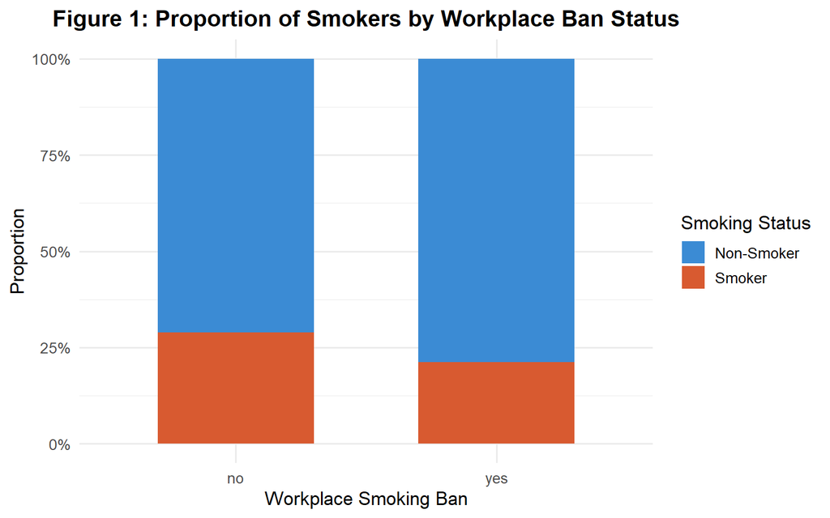

```r
ggplot(data, aes(x = ban, fill = smoker)) +
  geom_bar(position = "fill", width = 0.6) +
  scale_fill_manual(values = c("no" = "#3B8BD4", "yes" = "#D85A30"),
                    labels = c("Non-Smoker", "Smoker")) +
  scale_y_continuous(labels = scales::percent) +
  labs(
    title    = "Figure 1: Proportion of Smokers by Workplace Ban Status",
    x        = "Workplace Smoking Ban",
    y        = "Proportion",
    fill     = "Smoking Status"
  ) +
  theme_minimal(base_size = 13) +
  theme(plot.title = element_text(face = "bold", hjust = 0.5))
```

**Interpretation:** Figure 1 clearly shows that the proportion of smokers is lower among individuals with a workplace smoking ban (approximately 21%) compared to those without a ban (approximately 29%). This visual difference supports the hypothesis that bans are associated with reduced smoking.

## 4.2 Visualisation 2: Age Distribution by Smoking Status

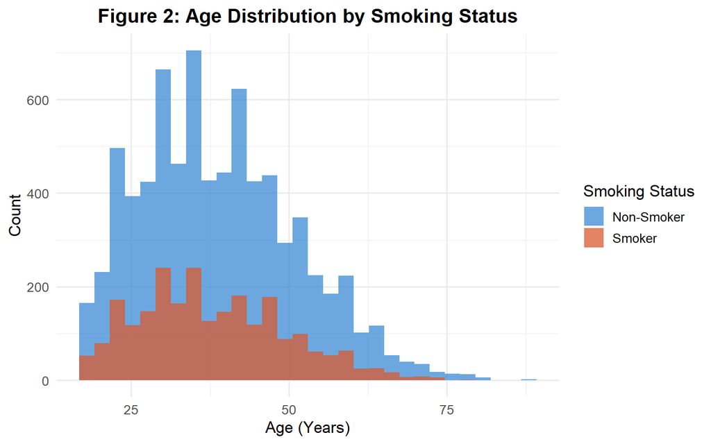

```r
ggplot(data, aes(x = age, fill = smoker)) +
  geom_histogram(bins = 30, alpha = 0.75, position = "identity") +
  scale_fill_manual(values = c("no" = "#3B8BD4", "yes" = "#D85A30"),
                    labels = c("Non-Smoker", "Smoker")) +
  labs(
    title = "Figure 2: Age Distribution by Smoking Status",
    x     = "Age (Years)",
    y     = "Count",
    fill  = "Smoking Status"
  ) +
  theme_minimal(base_size = 13) +
  theme(plot.title = element_text(face = "bold", hjust = 0.5))
```

**Interpretation:** Figure 2 shows the age distributions of smokers and non-smokers are broadly similar, though smokers appear slightly more concentrated in younger and middle-age groups. This suggests age may play a modest role in smoking behaviour.

## 4.3 Visualisation 3: Smoking Rate by Education Level

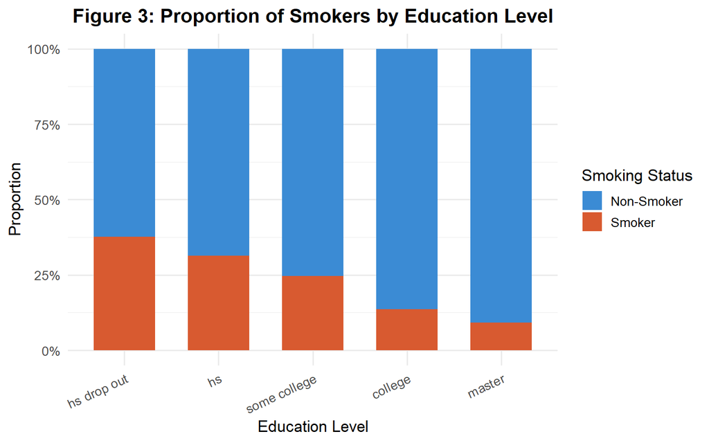

```r
ggplot(data, aes(x = education, fill = smoker)) +
  geom_bar(position = "fill", width = 0.65) +
  scale_fill_manual(values = c("no" = "#3B8BD4", "yes" = "#D85A30"),
                    labels = c("Non-Smoker", "Smoker")) +
  scale_y_continuous(labels = scales::percent) +
  labs(
    title = "Figure 3: Proportion of Smokers by Education Level",
    x     = "Education Level",
    y     = "Proportion",
    fill  = "Smoking Status"
  ) +
  theme_minimal(base_size = 13) +
  theme(
    axis.text.x  = element_text(angle = 25, hjust = 1),
    plot.title   = element_text(face = "bold", hjust = 0.5)
  )
```

**Interpretation:** Figure 3 reveals a clear negative relationship between education level and smoking. Individuals who dropped out of high school have the highest smoking rates, while those with a Master’s degree have the lowest. This pattern is consistent with the well-documented inverse relationship between educational attainment and smoking behaviour.